# Storm Data Analysis of finding the most harmful weather disaster in U.S.

HPSUN

2017年12月1日

## Synopsis

```r
library(readr)
storm <- read_csv("StormData.csv.bz2")
```

### check how many types of events

The top 100 events recorded are list below

```r
a <- sort(table(storm$EVTYPE),decreasing = T)
head(a,100)
```

```
##
##                     HAIL                TSTM WIND        THUNDERSTORM WIND
##                   288661                   219944                    82563
##                  TORNADO              FLASH FLOOD                    FLOOD
##                    60652                    54278                    25326
##       THUNDERSTORM WINDS                HIGH WIND                LIGHTNING
##                    20843                    20212                    15755
##               HEAVY SNOW               HEAVY RAIN             WINTER STORM
##                    15708                    11723                    11433
##           WINTER WEATHER             FUNNEL CLOUD         MARINE TSTM WIND
##                     7026                     6839                     6175
## MARINE THUNDERSTORM WIND               WATERSPOUT              STRONG WIND
##                     5812                     3797                     3566
##     URBAN/SML STREAM FLD                 WILDFIRE                 BLIZZARD
##                     3392                     2761                     2719
##                  DROUGHT                ICE STORM           EXCESSIVE HEAT
##                     2488                     2006                     1678
##               HIGH WINDS         WILD/FOREST FIRE             FROST/FREEZE
##                     1533                     1457                     1342
##                DENSE FOG       WINTER WEATHER/MIX           TSTM WIND/HAIL
##                     1293                     1104                     1028
##  EXTREME COLD/WIND CHILL                     HEAT                HIGH SURF
##                     1002                      767                      725
##           TROPICAL STORM           FLASH FLOODING             EXTREME COLD
##                      690                      682                      655
##            COASTAL FLOOD         LAKE-EFFECT SNOW        FLOOD/FLASH FLOOD
##                      651                      636                      624
##                LANDSLIDE                     SNOW          COLD/WIND CHILL
##                      600                      587                      539
##                      FOG              RIP CURRENT              MARINE HAIL
##                      538                      470                      442
##               DUST STORM                AVALANCHE                     WIND
##                      427                      386                      341
##             RIP CURRENTS              STORM SURGE            FREEZING RAIN
##                      304                      261                      250
##              URBAN FLOOD     HEAVY SURF/HIGH SURF        EXTREME WINDCHILL
##                      249                      228                      204
##             STRONG WINDS           DRY MICROBURST    ASTRONOMICAL LOW TIDE
##                      196                      186                      174
##                HURRICANE              RIVER FLOOD               LIGHT SNOW
```

[output cut: 14 more lines]

```
##                       64                       61                       61
##      TROPICAL DEPRESSION                    SLEET         UNSEASONABLY DRY
##                       60                       59                       56
##                    FROST              GUSTY WINDS      THUNDERSTORM WINDSS
##                       53                       53                       51
##       MARINE STRONG WIND                    OTHER               SMALL HAIL
##                       48                       48                       47
##                   FUNNEL             FREEZING FOG             THUNDERSTORM
##                       46                       45                       45
##       Temperature record          TSTM WIND (G45)         Coastal Flooding
##                       43                       40                       38
##              WATERSPOUTS    MONTHLY PRECIPITATION                    WINDS
##                       37                       36                       36
##      MIXED PRECIPITATION
##                       34
```

The mean records for a event is calculated as total counts devided by numbers of event type

```r
sum(a)
```

```
## [1] 902297
```

```r
length(a)
```

```
## [1] 977
```

```r
sum(a) / length(a)
```

```
## [1] 923.5384
```

From these results, we can tell that, although there over 900 types of events, but only a few are common. If we want to know the most harmful event, maybe we shold just take the top ones into consideration to save calculation.  
So, I extrat the events over the mean records for further calculation.

```r
sub_storm <- subset(storm,storm$EVTYPE %in% names(which(a>(sum(a) / length(a)))))
sub_storm <- subset(sub_storm, select = c(EVTYPE,FATALITIES,INJURIES,PROPDMG,PROPDMGEXP,CROPDMG,CROPDMGEXP))
```

for the damage part, we need to calculate the reall number combine the number(PROPDMG,CROPDMG) and the order of magnitude (PROPDMGEXP,CROPDMGEXP) first, let’s find out what kinds of mark in PROPDMGEXP and CROPDMGEXP

```r
table(sub_storm$PROPDMGEXP)
```

```
##
##      -      ?      +      0      1      2      3      4      5      6
##      1      8      3    212     23     13      4      2     25      4
##      7      8      B      H      K      m      M
##      5      1     14      6 416846      6  10745
```

```r
table(sub_storm$CROPDMGEXP)
```

```
##
##      ?      0      2      B      k      K      M
##      4     18      1      5     19 276326   1790
```

we will set “-”,“?”,“+” to 0; “H” stands for hundred, so it’s 2;“K”,“k” are 3; “M” is 6; “B” is 9.

```r
sub_storm[which(sub_storm$PROPDMGEXP=="-"|sub_storm$PROPDMGEXP=="?"|sub_storm$PROPDMGEXP=="+"),"PROPDMGEXP"] <- 0
sub_storm[which(sub_storm$PROPDMGEXP=="B"),"PROPDMGEXP"] <- 9
sub_storm[which(sub_storm$PROPDMGEXP=="H"),"PROPDMGEXP"] <- 2
sub_storm[which(sub_storm$PROPDMGEXP=="K"),"PROPDMGEXP"] <- 3
sub_storm[which(sub_storm$PROPDMGEXP=="m"),"PROPDMGEXP"] <- 6
sub_storm[which(sub_storm$PROPDMGEXP=="M"),"PROPDMGEXP"] <- 6
sub_storm[which(sub_storm$CROPDMGEXP=="?"),"CROPDMGEXP"] <- 0
sub_storm[which(sub_storm$CROPDMGEXP=="B"),"CROPDMGEXP"] <- 9
sub_storm[which(sub_storm$CROPDMGEXP=="k"),"CROPDMGEXP"] <- 3
sub_storm[which(sub_storm$CROPDMGEXP=="K"),"CROPDMGEXP"] <- 3
sub_storm[which(sub_storm$CROPDMGEXP=="M"),"CROPDMGEXP"] <- 6
sub_storm$PROPDMGEXP <- as.numeric(sub_storm$PROPDMGEXP)
sub_storm$CROPDMGEXP <- as.numeric(sub_storm$CROPDMGEXP)
```

we calculate the real cost and store it

```r
sub_storm$PROPDMGCOST <- sub_storm$PROPDMG*(10^sub_storm$PROPDMGEXP)
sub_storm$CROPDMGCOST <- sub_storm$CROPDMG*(10^sub_storm$CROPDMGEXP)
```

## Results

### Events harmful to population health

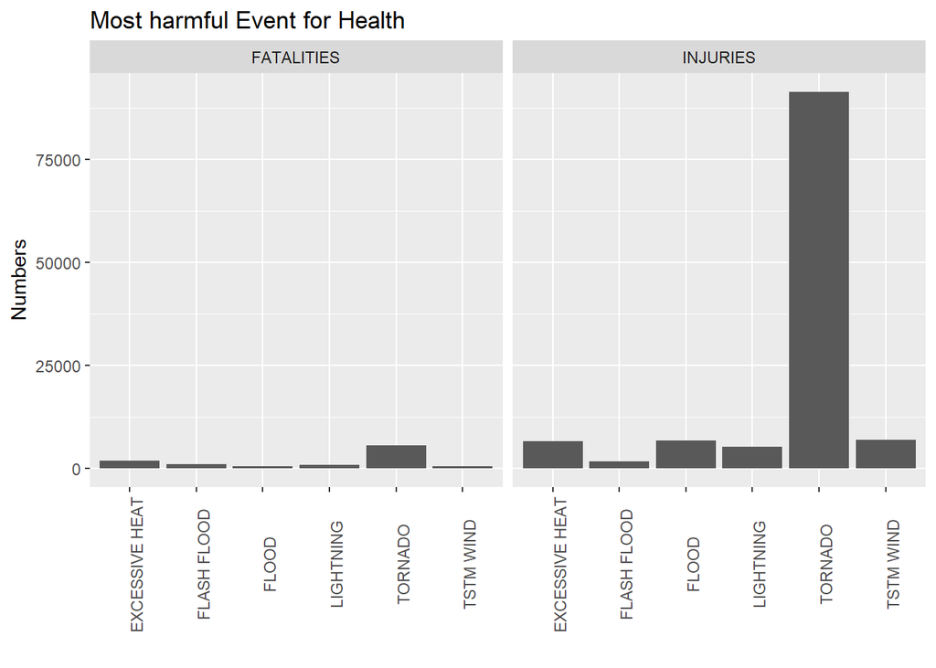

```r
library(ggplot2)
library(reshape2)
pop <- sub_storm[,c("EVTYPE","FATALITIES","INJURIES")]
a_pop <- aggregate(. ~ EVTYPE,data = pop,sum)
top_F <- order(a_pop$FATALITIES,decreasing = T)[1:5]
top_I <- order(a_pop$INJURIES,decreasing = T)[1:5]
top <- unique(c(top_F,top_I))
x <- a_pop[top,]
y <- melt(x)
g <- ggplot(y,aes(EVTYPE,value))
g <- g + geom_col() + facet_grid(. ~ variable)
g + theme(axis.text.x = element_text(angle=90)) + labs(y="Numbers",x="",title="Most harmful Event for Health")
```

### Events cause greatest economic consequences

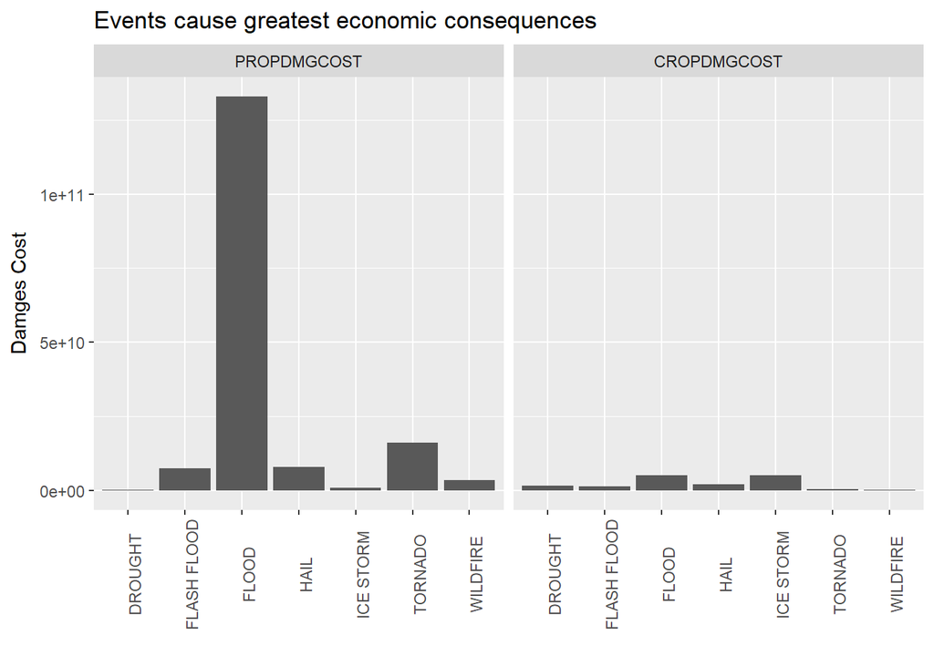

```r
eco <- sub_storm[,c("EVTYPE","PROPDMGCOST","CROPDMGCOST")]
a_eco <- aggregate(. ~ EVTYPE,data = eco,sum)
top_P <- order(a_eco$PROPDMGCOST,decreasing = T)[1:5]
top_C <- order(a_eco$CROPDMGCOST,decreasing = T)[1:5]
top <- unique(c(top_P,top_C))
x <- a_eco[top,]
y <- melt(x)
g <- ggplot(y,aes(EVTYPE,value))
g <- g + geom_col() + facet_grid(. ~ variable)
g + theme(axis.text.x = element_text(angle=90)) + labs(y="Damges Cost",x="",title="Events cause greatest economic consequences")
```

### conclusion

From above, we found that tornado is most harmful to population health and flood casued greatest economic consequences.